# HW MD 7

## Question 2

```r
fifty_propershovel <-
  nobel_winners_flt|>
  rep_sample_n(size = 25,
               reps = 50) |>
  group_by(replicate) |>
  summarise(prop = sum(is_us)/25)
```

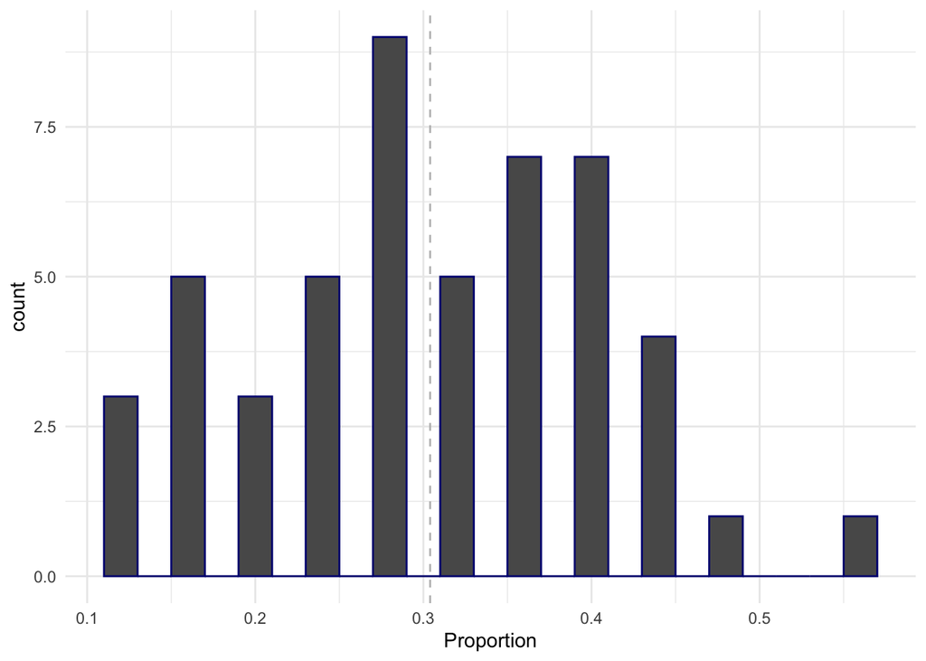

```r
ggplot(data = fifty_propershovel,
       mapping = aes(x = prop))+
  geom_histogram(binwidth = 0.02, color = "navy")+
  geom_vline(aes(xintercept = mean(prop)),
             color="grey", linetype="dashed", size=.5) +
  labs(x = "Proportion")
```

## Question 3

```r
hunnid_propershovel <-
  nobel_winners_flt|>
  rep_sample_n(size = 100,
               reps = 50) |>
  group_by(replicate) |>
  summarise(prop = sum(is_us)/100)
```

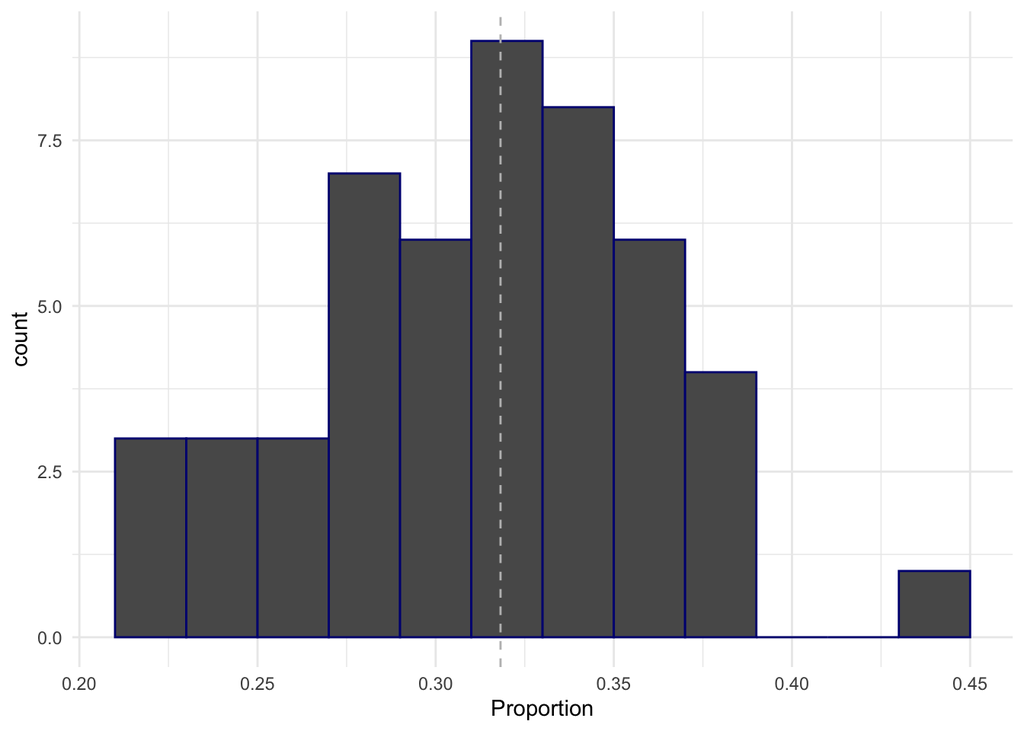

```r
ggplot(data = hunnid_propershovel,
       mapping = aes(x = prop))+
  geom_histogram(binwidth = 0.02, color = "navy")+
  geom_vline(aes(xintercept = mean(prop)),
             color="grey", linetype="dashed", size=.5) +
  labs(x = "Proportion")
```

There appears to be more variety in the distribution with 50 samples of 25 winners each over the distribution with 50 samples and 100 winners each. I think this is because as sample size increases, the variety of sampling distribution decreases, and we get more values closer to the average.

## Question 4

```r
std25 <- fifty_propershovel$prop

sd(std25)
```

```
[1] 0.1031741
```

```r
std100 <- hunnid_propershovel$prop

sd(std100)
```

```
[1] 0.04766764
```

The standard deviation tells above proves that the larger the sample size the lower the variation and therefore the lower the standard deviation.

## Question 5

```r
nobelwinners_women<- nobel_winners_flt |>
  mutate(gender1 = if_else(gender=="Female",1,0))
```

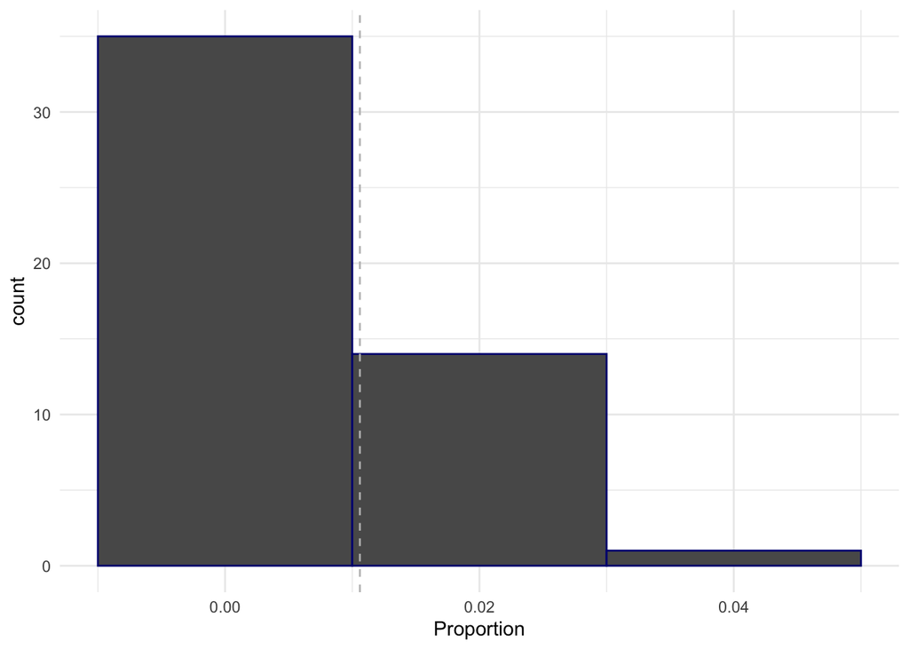

```r
female_100 <- nobelwinners_women |>
  rep_sample_n(size = 25,
               reps = 50) |>
  group_by(replicate) |>
  summarise(prop = sum(gender1)/100)

ggplot(data =female_100,
       mapping = aes(x = prop)) +
  geom_histogram(binwidth = 0.02, color = "navy") +
  geom_vline(aes(xintercept = mean(prop)),
             color="grey", linetype="dashed", size=.5) +
  labs(x = "Proportion")
```

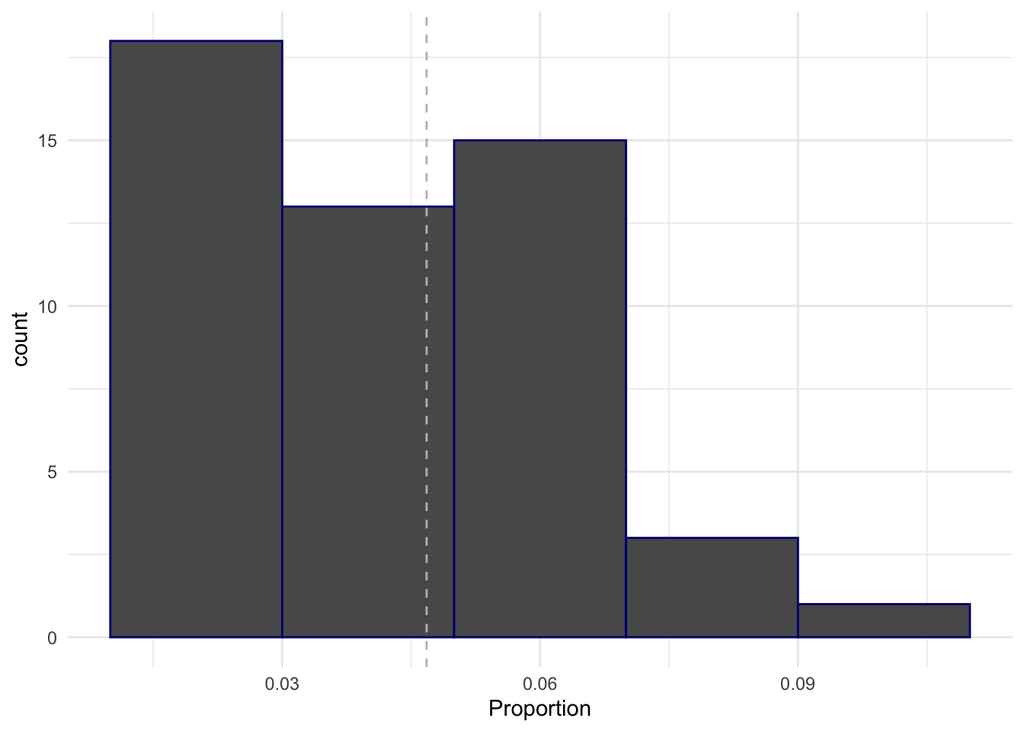

```r
female_100 <- nobelwinners_women |>
  rep_sample_n(size = 100,
               reps = 50) |>
  group_by(replicate) |>
  summarise(prop = sum(gender1)/100)

ggplot(data =female_100,
       mapping = aes(x = prop)) +
  geom_histogram(binwidth = 0.02, color = "navy") +
  geom_vline(aes(xintercept = mean(prop)),
             color="grey", linetype="dashed", size=.5) +
  labs(x = "Proportion")
```

## Question 6

The central limit theorem is a theorem that states that as a sample size increases, the distribution of averages will appear more ‘normal’ and narrower. This will represent more of a bell-like function, and the higher sample size will more closely represent the true mean of a population’s whole.